# Mini Project 2

Mae Rosenstein, Chelsey Chen, Talia Seshaiah

March 22, 2018

The data represented in these visualizations originate from the Federal Election Commission. The data is focused around the 2011 - 2013 election cycle. The candidates are those who have registered with the Federal Election Commission or are present on an official ballot list from a given state’s elections office. The contributions to candidates are ones that have been received from itemized committees, PAC contributions to a party committee, party transfers between state committees, and party transfers from a national committee to a state committee. The contributions highlighted in these visualizations are only independent expenditures advocating for election of the specified candidate.

```r
library(tidyverse)
library(fiftystater)
library(mapproj)
library(RColorBrewer)
```

## Data Wrangling

```r
contri_candi <- contributions %>%
  filter(transaction_type == "24E",
         transaction_amt >= 0,
         entity_type != "") %>%
  left_join(candidates, by = "cand_id") %>%
  filter(cand_party_affiliation %in% c('REP','DEM','IND','LIB')) %>%
  select(cand_party_affiliation, transaction_amt, transaction_dt, cand_name, entity_type,state) %>%
  mutate(date = as.Date(transaction_dt, "%m%d%Y"),
         year = substr(date,0,4)) %>%
  select(-transaction_dt) %>%
  filter(date <= '2012-12-31',
         date >= '2011-01-01') %>%
  mutate(cand_party_affiliation = ifelse(cand_party_affiliation == 'REP', 'Republican', cand_party_affiliation),
         cand_party_affiliation = ifelse(cand_party_affiliation == 'DEM', 'Democratic', cand_party_affiliation),
         cand_party_affiliation = ifelse(cand_party_affiliation == 'LIB', 'Libertarian', cand_party_affiliation),
         cand_party_affiliation = ifelse(cand_party_affiliation == 'IND', 'Independent', cand_party_affiliation)) %>%
  group_by(cand_name,cand_party_affiliation,date,year,entity_type,state) %>%
  summarize(total_amt = sum(transaction_amt))
```

## Data Visualizations

### Figure 1: The contribution amount given to the republican party, democratic party, independent party, and libertarian party from January 1, 2011 to December 31, 2012.

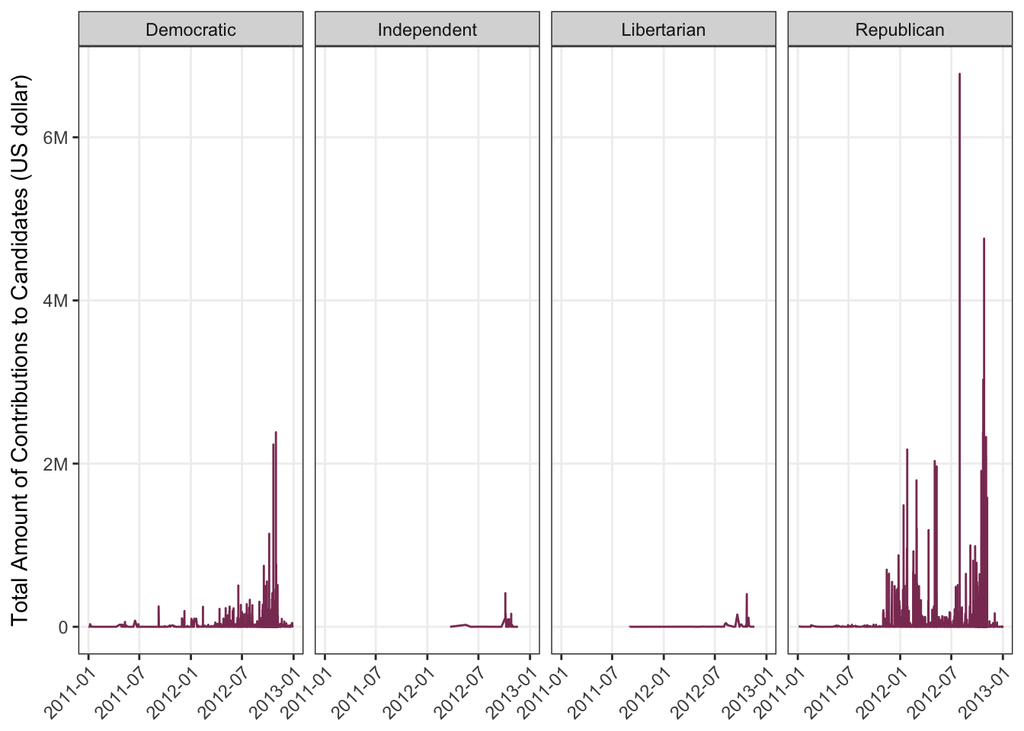

```r
# Write a function to plot the graph given a specific source of contribution and a color
graph_fun <- function(entity, colour){
  contri_candi %>%
  filter(entity_type == entity) %>%
  ggplot(aes(x=date, y= total_amt)) +
  geom_line(color = colour) +
  theme_bw() +
  labs(x = NULL,
       y = "Total Amount of Contributions to Candidates (US dollar)") +
  scale_y_continuous(breaks = c(0,2000000,4000000,6000000,8000000),
                     labels = c("0","2M", "4M", "6M","8M")) +
  theme(axis.text.x = element_text(angle = 45, hjust =1),
        panel.grid.major = element_line(colour = "grey94"),
        panel.grid.minor = element_line(colour = "white")) +
  facet_grid(~cand_party_affiliation)
}

my_plot1 <- graph_fun("ORG","hotpink4")
my_plot1
```

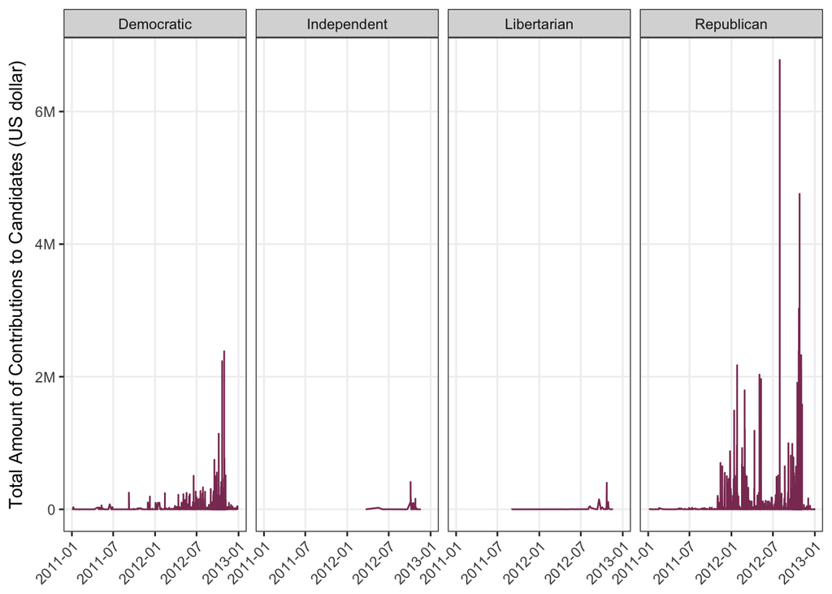

```r
# Call the graphing function for contributions made by orgnizations
my_plot1 <- graph_fun("ORG","hotpink4")
my_plot1
```

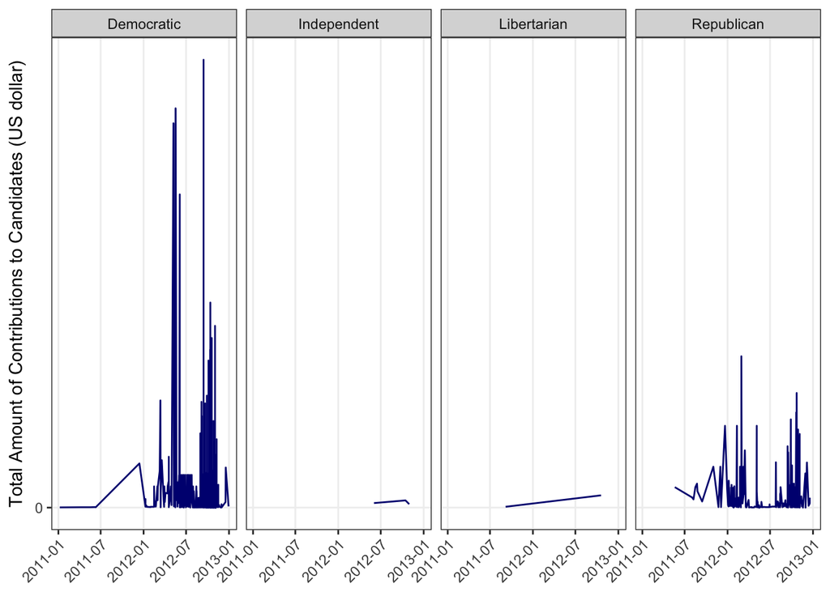

```r
# # Call the graphing function for contributions made by individuals

my_plot2 <- graph_fun("IND","navyblue")
my_plot2
```

This visualization displays the total amount of contributions by party affiliation. The data was filtered to span from January 1, 2011 to January 1, 2013. The contributions included in the visualization are from various types of contriubtors ranging from large organizations to individuals. The parties highlighted in the visualization are democratic party, republican party, libertarian party, and independent. The republican and democratic parties received the most contributions, however the republican party received the most contributions as seen in the visualization. These results are not surprising due to the fact the the democratic party and republican party are the primary political parties.

### Figure 2: Contributions made by different states

```r
# Read 52 state codes into a local dataframe [includes DC (Washington D.C. and PR (Puerto Rico)]
st.codes<-data.frame(abb=as.factor(c("AK", "AL", "AR", "AZ", "CA", "CO", "CT", "DC", "DE", "FL", "GA",
                                         "HI", "IA", "ID", "IL", "IN", "KS", "KY", "LA", "MA", "MD", "ME",
                                         "MI", "MN", "MO", "MS",  "MT", "NC", "ND", "NE", "NH", "NJ", "NM",
                                         "NV", "NY", "OH", "OK", "OR", "PA", "PR", "RI", "SC", "SD", "TN",
                                         "TX", "UT", "VA", "VT", "WA", "WI", "WV", "WY")),
                      state=as.factor(c("alaska","alabama","arkansas","arizona","california","colorado",
                                       "connecticut","district of columbia","delaware","florida","georgia",
                                       "hawaii","iowa","idaho","illinois","indiana","kansas","kentucky",
                                       "louisiana","massachusetts","maryland","maine","michigan","minnesota",
                                       "missouri","mississippi","montana","north carolina","north dakota",
                                       "nebraska","new hampshire","new jersey","new mexico","nevada",
                                       "new york","ohio","oklahoma","oregon","pennsylvania","puerto rico",
                                       "rhode island","south carolina","south dakota","tennessee","texas",
                                       "utah","virginia","vermont","washington","wisconsin",
                                       "west virginia","wyoming"))
                     )

# Join the created st.codes dataframe with our dataframe by the state name
contri_candi <- contri_candi %>%
  right_join(st.codes, state = state) %>%
  select(-abb)
```

[figure not shown]

```r
# Create a summary dataframe calculating total contributions for a given party affiliation,year,source,and state
state.summary <- contri_candi %>%
  group_by(cand_party_affiliation, year, entity_type, state) %>%
  summarize(total = sum(total_amt)) %>%
  filter(!is.na(total))

# Create a custom color palette (diverging colors)
myPalette <- colorRampPalette(rev(brewer.pal(9, "RdGy")))

# Create a map showing contributions to Republican candidates made by orgnizations in 2012 by different states
my_plot3 <- state.summary %>%
  filter(entity_type == "ORG",
         cand_party_affiliation == "Republican",
         year == 2012) %>%
  ggplot(aes(map_id = state)) +
  geom_map(aes(fill = total), map = fifty_states) +
  expand_limits(x = fifty_states$long, y = fifty_states$lat) +
  coord_map() +
  scale_x_continuous(breaks = NULL) +
  scale_y_continuous(breaks = NULL) +
  scale_fill_gradientn(colors = myPalette(4:9),
                       breaks=c(1000,50000000),
                       labels=c("1K","50M"),
                       limits=c(1000,50000000),
                       guide = guide_colorbar(title = "Amount of Contributions")) +
  labs(x = "", y = "") +
  theme(panel.background = element_blank())
my_plot3
```

Link to GitHub repository: https://github.com/mrosenstein/sds192-mp2.git